# Assignment 1 - Regularization with Ridge and Lasso Regressions

# Zeel Patel

## Part A: Coding

### 1. Load the dataset, determine target, standardize the features and train/test split

```python
import pandas as pd
import numpy as np
from sklearn.model_selection import train_test_split
from sklearn.preprocessing import StandardScaler
```

```python
from sklearn.datasets import load_diabetes
diabetes = load_diabetes()
X = diabetes.data
y = diabetes.target
feature_names = diabetes.feature_names

# Converting to dataframe
df_diabetes = pd.DataFrame(X, columns=feature_names)
df_diabetes['target'] = y

# Printing shape of dataset
print("Shape of dataset:", df_diabetes.shape)
df_diabetes.head()
```

```
Shape of dataset: (442, 11)
```

|  | age | sex | bmi | bp | s1 | s2 | s3 | s4 | s5 | s6 | target |
| --- | --- | --- | --- | --- | --- | --- | --- | --- | --- | --- | --- |
| 0 | 0.038076 | 0.050680 | 0.061696 | 0.021872 | -0.044223 | -0.034821 | -0.043401 | -0.002592 | 0.019907 | -0.017646 | 151.0 |
| 1 | -0.001882 | -0.044642 | -0.051474 | -0.026328 | -0.008449 | -0.019163 | 0.074412 | -0.039493 | -0.068332 | -0.092204 | 75.0 |
| 2 | 0.085299 | 0.050680 | 0.044451 | -0.005670 | -0.045599 | -0.034194 | -0.032356 | -0.002592 | 0.002861 | -0.025930 | 141.0 |
| 3 | -0.089063 | -0.044642 | -0.011595 | -0.036656 | 0.012191 | 0.024991 | -0.036038 | 0.034309 | 0.022688 | -0.009362 | 206.0 |
| 4 | 0.005383 | -0.044642 | -0.036385 | 0.021872 | 0.003935 | 0.015596 | 0.008142 | -0.002592 | -0.031988 | -0.046641 | 135.0 |

```python
# Understanding the summarization of dataset
df_diabetes.describe()
```

|  | age | sex | bmi | bp | s1 | s2 | s3 | s4 | s5 | s6 | target |
| --- | --- | --- | --- | --- | --- | --- | --- | --- | --- | --- | --- |
| count | 4.420000e+02 | 4.420000e+02 | 4.420000e+02 | 4.420000e+02 | 4.420000e+02 | 4.420000e+02 | 4.420000e+02 | 4.420000e+02 | 4.420000e+02 | 4.420000e+02 | 442.000000 |
| mean | -2.511817e-19 | 1.230790e-17 | -2.245564e-16 | -4.797570e-17 | -1.381499e-17 | 3.918434e-17 | -5.777179e-18 | -9.042540e-18 | 9.293722e-17 | 1.130318e-17 | 152.133484 |
| std | 4.761905e-02 | 4.761905e-02 | 4.761905e-02 | 4.761905e-02 | 4.761905e-02 | 4.761905e-02 | 4.761905e-02 | 4.761905e-02 | 4.761905e-02 | 4.761905e-02 | 77.093005 |
| min | -1.072256e-01 | -4.464164e-02 | -9.027530e-02 | -1.123988e-01 | -1.267807e-01 | -1.156131e-01 | -1.023071e-01 | -7.639450e-02 | -1.260971e-01 | -1.377672e-01 | 25.000000 |
| 25% | -3.729927e-02 | -4.464164e-02 | -3.422907e-02 | -3.665608e-02 | -3.424784e-02 | -3.035840e-02 | -3.511716e-02 | -3.949338e-02 | -3.324559e-02 | -3.317903e-02 | 87.000000 |
| 50% | 5.383060e-03 | -4.464164e-02 | -7.283766e-03 | -5.670422e-03 | -4.320866e-03 | -3.819065e-03 | -6.584468e-03 | -2.592262e-03 | -1.947171e-03 | -1.077698e-03 | 140.500000 |
| 75% | 3.807591e-02 | 5.068012e-02 | 3.124802e-02 | 3.564379e-02 | 2.835801e-02 | 2.984439e-02 | 2.931150e-02 | 3.430886e-02 | 3.243232e-02 | 2.791705e-02 | 211.500000 |
| max | 1.107267e-01 | 5.068012e-02 | 1.705552e-01 | 1.320436e-01 | 1.539137e-01 | 1.987880e-01 | 1.811791e-01 | 1.852344e-01 | 1.335973e-01 | 1.356118e-01 | 346.000000 |

```python
# Printing information about dataset
df_diabetes.info()
```

```
<class 'pandas.core.frame.DataFrame'>
RangeIndex: 442 entries, 0 to 441
Data columns (total 11 columns):
 #   Column  Non-Null Count  Dtype
---  ------  --------------  -----
 0   age     442 non-null    float64
 1   sex     442 non-null    float64
 2   bmi     442 non-null    float64
 3   bp      442 non-null    float64
 4   s1      442 non-null    float64
 5   s2      442 non-null    float64
 6   s3      442 non-null    float64
 7   s4      442 non-null    float64
 8   s5      442 non-null    float64
 9   s6      442 non-null    float64
 10  target  442 non-null    float64
dtypes: float64(11)
memory usage: 38.1 KB
```

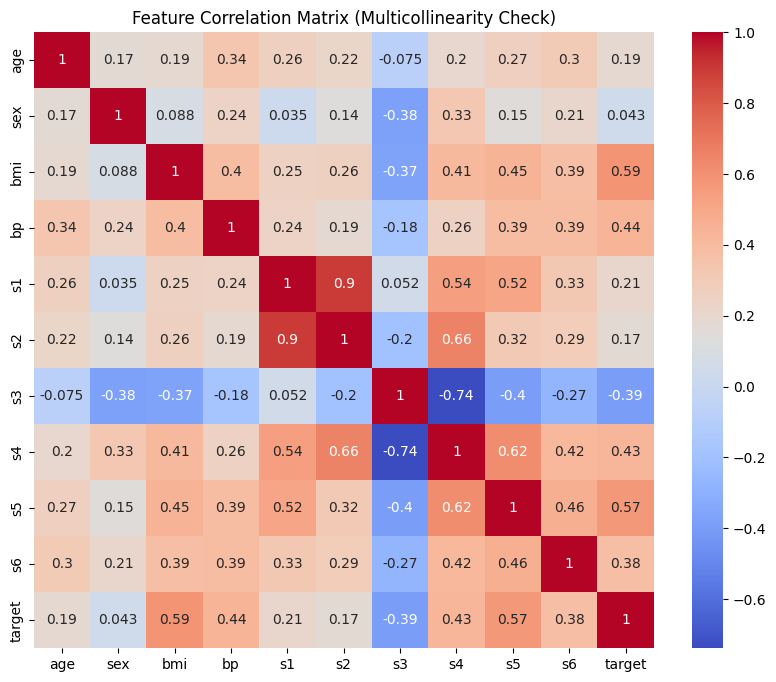

```python
# Correlation matrix
import matplotlib.pyplot as plt
import seaborn as sns
corr_matrix = df_diabetes.corr()
plt.figure(figsize=(10, 8))
sns.heatmap(corr_matrix, annot=True, cmap='coolwarm')
plt.title("Feature Correlation Matrix (Multicollinearity Check)")
plt.show()
```

#### Splitting into training and testing datasets

```python
from sklearn.model_selection import train_test_split

X_train, X_test, y_train, y_test = train_test_split(
    X, y, test_size=0.2, random_state=42
)

print("Training features shape:", X_train.shape)
print("Testing features shape:", X_test.shape)
print("Training target shape:", y_train.shape)
print("Testing target shape:", y_test.shape)
```

```
Training features shape: (353, 10)
Testing features shape: (89, 10)
Training target shape: (353,)
Testing target shape: (89,)
```

### 2. Build OLS regression model, calculate the MSE test

```python
from sklearn.linear_model import LinearRegression
from sklearn.metrics import mean_squared_error

ols = LinearRegression()
ols.fit(X_train, y_train)

y_pred_ols = ols.predict(X_test)

mse_ols = mean_squared_error(y_test, y_pred_ols)

print("OLS Test MSE:", mse_ols)
```

```
OLS Test MSE: 2900.19362849348
```

### 3. Define a range of lambda (alpha in code) values to use for regularization

```python
import numpy as np

alphas = np.logspace(-4, 4, 100)

print("Sample alpha values:", alphas[:5], "...", alphas[-5:])
```

```
Sample alpha values: [0.0001     0.00012045 0.00014508 0.00017475 0.00021049] ... [ 4750.8101621   5722.36765935  6892.61210435  8302.17568132
 10000.        ]
```

### 4. For both Ridge and Lasso, plot the coefficients as a function of the alphas

#### Lasso Coefficients vs Alpha

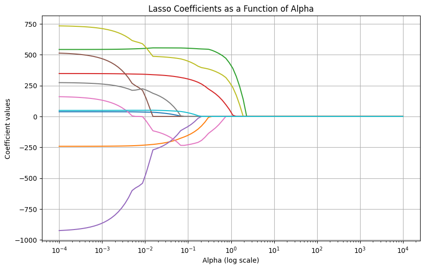

```python
from sklearn.linear_model import Lasso
import warnings
from sklearn.exceptions import ConvergenceWarning
import matplotlib.pyplot as plt

warnings.filterwarnings("ignore", category=ConvergenceWarning)

lasso_coefs = []

for alpha in alphas:
    lasso = Lasso(alpha=alpha, max_iter=10000)
    lasso.fit(X_train, y_train)
    lasso_coefs.append(lasso.coef_)

plt.figure(figsize=(10, 6))
plt.plot(alphas, lasso_coefs)
plt.xscale("log")
plt.xlabel("Alpha (log scale)")
plt.ylabel("Coefficient values")
plt.title("Lasso Coefficients as a Function of Alpha")
plt.grid(True)
plt.show()
```

#### Graph Interpretation

- At a low alpha, almost all coefficients are non-zero.
- All features have an influence on the prediction
- As alpha increases, Lasso starts shrinking the coefficients and they gradually move towards zero.
- At an very high alpha in our range, most of the coefficients are exactly zero

#### Ridge Coefficients vs Alpha

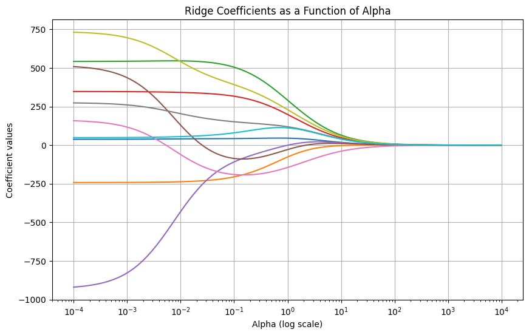

```python
import matplotlib.pyplot as plt
from sklearn.linear_model import Ridge

ridge_coefs = []

for alpha in alphas:
    ridge = Ridge(alpha=alpha)
    ridge.fit(X_train, y_train)
    ridge_coefs.append(ridge.coef_)

plt.figure(figsize=(10, 6))
plt.plot(alphas, ridge_coefs)
plt.xscale("log")
plt.xlabel("Alpha (log scale)")
plt.ylabel("Coefficient values")
plt.title("Ridge Coefficients as a Function of Alpha")
plt.grid(True)
plt.show()
```

### 5. For both Ridge and Lasso, plot the train MSE as a function of the alphas

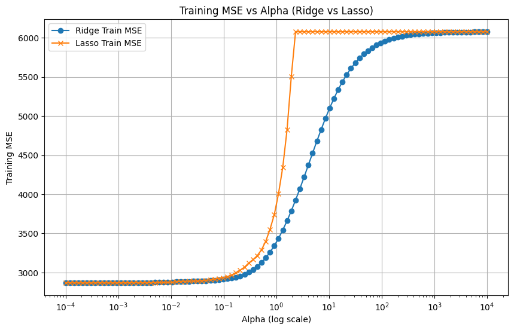

```python
train_mse_ridge = []
train_mse_lasso = []

for alpha in alphas:
    # Ridge
    ridge = Ridge(alpha=alpha)
    ridge.fit(X_train, y_train)
    y_train_pred_ridge = ridge.predict(X_train)
    train_mse_ridge.append(mean_squared_error(y_train, y_train_pred_ridge))

    # Lasso
    lasso = Lasso(alpha=alpha, max_iter=10000)
    lasso.fit(X_train, y_train)
    y_train_pred_lasso = lasso.predict(X_train)
    train_mse_lasso.append(mean_squared_error(y_train, y_train_pred_lasso))

plt.figure(figsize=(10, 6))
plt.plot(alphas, train_mse_ridge, label="Ridge Train MSE", marker='o')
plt.plot(alphas, train_mse_lasso, label="Lasso Train MSE", marker='x')
plt.xscale("log")
plt.xlabel("Alpha (log scale)")
plt.ylabel("Training MSE")
plt.title("Training MSE vs Alpha (Ridge vs Lasso)")
plt.legend()
plt.grid(True)
plt.show()
```

#### Graph Interpretation

- At low alpha values, both Ridge and Lasso have low training MSE, indicating a close fit to the training data.
- As alpha increases:
  - Ridge MSE increases gradually.
  - Lasso MSE increases sharply.
- Beyond a certain threshold (around alpha ≈ 10), both models show significantly higher training error, this could mean that they are underfitting the data.

### 6. Use RidgeCV and LassoCV to determine the optimal alpha as a function of the training MSE

```python
from sklearn.linear_model import RidgeCV, LassoCV

ridge_cv = RidgeCV(alphas=alphas, scoring='neg_mean_squared_error', cv=5)
ridge_cv.fit(X_train, y_train)
best_alpha_ridge = ridge_cv.alpha_

lasso_cv = LassoCV(alphas=alphas, max_iter=10000, cv=5)
lasso_cv.fit(X_train, y_train)
best_alpha_lasso = lasso_cv.alpha_

print("Best alpha for Ridge:", best_alpha_ridge)
print("Best alpha for Lasso:", best_alpha_lasso)
```

```
Best alpha for Ridge: 0.06734150657750829
Best alpha for Lasso: 0.08111308307896872
```

### 7. For both Ridge and Lasso, calculate the test MSE

```python
from sklearn.linear_model import Ridge, Lasso
from sklearn.metrics import mean_squared_error

ridge_final = Ridge(alpha=best_alpha_ridge)
ridge_final.fit(X_train, y_train)
y_pred_ridge = ridge_final.predict(X_test)
mse_ridge = mean_squared_error(y_test, y_pred_ridge)

lasso_final = Lasso(alpha=best_alpha_lasso, max_iter=10000)
lasso_final.fit(X_train, y_train)
y_pred_lasso = lasso_final.predict(X_test)
mse_lasso = mean_squared_error(y_test, y_pred_lasso)

print("OLS Test MSE:", mse_ols)
print("Ridge Test MSE:", mse_ridge)
print("Lasso Test MSE:", mse_lasso)
```

```
OLS Test MSE: 2900.19362849348
Ridge Test MSE: 2862.00260262273
Lasso Test MSE: 2799.8279461101843
```

#### Interpretation:

All three models performed similarly, with Lasso regression achieving the lowest test MSE, followed by Ridge and OLS.

- The small performance gap suggests that the dataset is clean, and all features are reasonably relevant.
- Lasso outperformed slightly due to its ability to shrink and eliminate less useful coefficients, which helps reduce overfitting.
- Ridge also helped by reducing variance in the presence of multicollinearity, offering a modest improvement over OLS.

### 8. Recommend which algo to use based on the test MSE - OLS / Ridge / Lasso, and connect the recommendation to dataset characteristics

- The Diabetes dataset contains 10 numeric, standardized features. While all are relevant, some may have low predictive power or correlation with the target. Which is why Lasso may perform slightly better, by shrinking some coefficients to zero.
- Moderate multicollinearity exists between certain predictors (e.g., BMI, blood pressure, cholesterol), which can affect model stability.
- Lasso outperforms both OLS and Ridge in terms of test MSE by a small but meaningful margin.

So why are we picking Lasso?

- Lasso performs automatic feature selection by shrinking less relevant coefficients to exactly zero.
- This helps improve model generalization by reducing overfitting and simplifying the model.
- In contrast, Ridge retains all features and only shrinks coefficients, while OLS does not apply any regularization.

Conclusion:

- Given the presence of multicollinearity and potentially weak predictors, Lasso Regression is the best choice for this dataset. It balances predictive performance with simplicity and generalization.

## Part B: Conceptual Questions

#### 1. Why is it important to have a test set?

Having a test set is crucial because it gives us a realistic measure of how our model will perform on unseen data. When we train a model, it learns patterns from the training data — but if we only evaluate it on that same data, we can’t really tell if the model has actually learned something useful or if it’s just memorizing. The test set acts like a simulation of future data, helping us check whether the model will generalize well. Without a test set, we risk being overly optimistic about model performance and might deploy something that doesn’t actually work in practice.

#### 2. Why is regularization important? What happens if you do not do it?

Regularization is important because it helps prevent overfitting, especially when we have many features or correlated predictors. It does this by adding a penalty to large coefficient values, which encourages the model to keep things simpler and more robust.

If we don’t use regularization, especially in models like linear regression, the model can end up fitting noise instead of signal — meaning it performs well on training data but poorly on new, unseen data. This is particularly risky when there’s multicollinearity or when the dataset is small compared to the number of features.

#### 3. As we move further into Machine Learning, we will need to continually consider the bias-variance tradeoff. Explain what bias is and what variance is in regards to the bias-variance tradeoff.

Bias is the error from wrong assumptions in the model. A high-bias model is too simple to capture the underlying trend in the data — it underfits. For example, fitting a straight line to a clearly curved pattern.

Variance is the error from the model being too sensitive to fluctuations in the training data. A high-variance model learns too much detail (including noise), so it performs well on training data but poorly on new data — this is overfitting.

The bias-variance tradeoff is all about finding a sweet spot — a model that’s flexible enough to capture real patterns (low bias), but not so flexible that it memorizes noise (low variance).

#### 4. In a linear regression model, how might we reduce bias?

To reduce bias in a linear regression model, we can:

- Add more relevant features that help explain the outcome better
- Consider polynomial or interaction terms if we suspect non-linearity
- Use more complex models if the true relationship isn’t linear

Basically, we reduce bias by allowing the model to become more expressive, as long as we’re not overcomplicating it to the point of overfitting.

#### 5. In a linear regression model, how might we reduce variance?

To reduce variance, we can:

- Use regularization techniques like Ridge or Lasso
- Reduce the number of features (especially irrelevant or noisy ones)
- Increase the size of the training dataset (if possible)
- Use simpler models or restrict model flexibility

These steps help the model focus on core patterns instead of noise, making it more stable across different datasets.